# Models Analyser

Ashley

14 August, 2019

To analyse individual models copy the model name

## Champion Model

### Summary Regression Results

Summary Results for `DR~avg_oil_pri_barrel_lag_3+avg_oil_pri_barrel_lag_2`

| var | Estimates | VIF | p | se | t | DirectionCheck | Significance | Multicollinearity |
| --- | --- | --- | --- | --- | --- | --- | --- | --- |
| (Intercept) | 0.0438 | NA | 0 | 0.0022 | 19.7071 | NA | PASS | NA |
| avg_oil_pri_barrel_lag_2 | -0.0002 | 7.3369 | 0.0263 | 0.0001 | -2.3559 | PASS | PASS | FAIL |
| avg_oil_pri_barrel_lag_3 | -0.0002 | 7.3369 | 0.0143 | 0.0001 | -2.6249 | PASS | PASS | FAIL |

| R2 | 0.8710 |
| --- | --- |
| adjR2 | 0.8611 |
| MAPE_test | 0.1093 |

### Diagnostic Tests

Tests for stationarity for `DR~avg_oil_pri_barrel_lag_3+avg_oil_pri_barrel_lag_2`

| Check | Test | statistic | pvalue | Criteria | results | FINAL |
| --- | --- | --- | --- | --- | --- | --- |
| Heteroskedasticity | Breusch-Pagan Test | 1.7727 | 0.4122 | p > 0.1 | Homoskedasticity | PASS |
| Unit Root | ADF Test | -4.5742 | 0.01 | p < 0.1 | Stationary | PASS |
| Auto-Correlation | Durbin Watson Test | 0.8837 | 0.006 | p > 0.1 | Auto-Correlation | FAIL |
| Normality | Shapiro-Wilk Test | 0.8036 | 1e-04 | p > 0.1 | Residuals Not Normally Distributed | FAIL |

### Forecast

Observed versus Predicted Values for `DR~avg_oil_pri_barrel_lag_3+avg_oil_pri_barrel_lag_2`

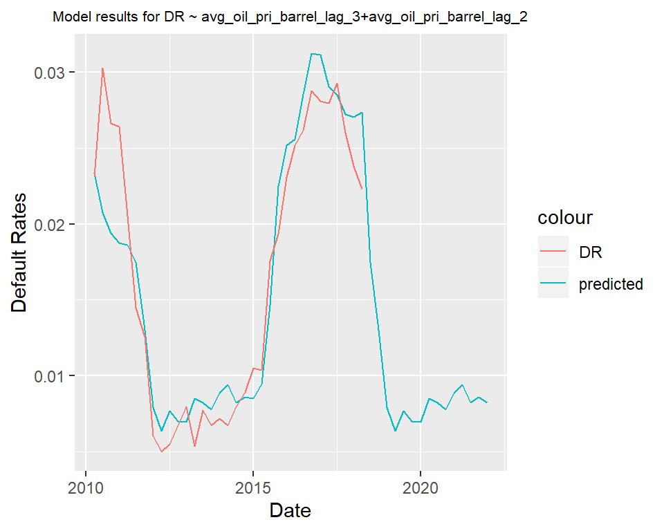

| Date | 31/03/2010 | 30/06/2010 | 30/09/2010 | 31/12/2010 | 31/03/2011 | 30/06/2011 | 30/09/2011 | 31/12/2011 | 31/03/2012 | 30/06/2012 | 30/09/2012 | 31/12/2012 | 31/03/2013 | 30/06/2013 | 30/09/2013 | 31/12/2013 | 31/03/2014 | 30/06/2014 | 30/09/2014 | 31/12/2014 | 31/03/2015 | 30/06/2015 | 30/09/2015 | 31/12/2015 | 31/03/2016 | 30/06/2016 | 30/09/2016 | 31/12/2016 | 31/03/2017 | … |
| --- | --- | --- | --- | --- | --- | --- | --- | --- | --- | --- | --- | --- | --- | --- | --- | --- | --- | --- | --- | --- | --- | --- | --- | --- | --- | --- | --- | --- | --- | --- |
| DR | 0.023055038 | 0.030261483 | 0.026615217 | 0.026397079 | 0.020515981 | 0.014480897 | 0.012552622 | 0.006055856 | 0.005017045 | 0.005498684 | 0.006715283 | 0.007955372 | 0.005346199 | 0.007736280 | 0.006724008 | 0.007176209 | 0.006743516 | 0.007946356 | 0.008899047 | 0.010515682 | 0.010357205 | 0.017554729 | 0.019339632 | 0.023058350 | 0.025162470 | 0.026158368 | 0.028763978 | 0.028075560 | 0.027932088 | … |
| avg_oil_pri_barrel_lag_3 | 58.69667 | 68.20000 | 74.63000 | 76.25000 | 78.51000 | 76.82000 | 86.46667 | 104.96000 | 117.36000 | 113.34000 | 109.39667 | 118.49000 | 108.41667 | 109.61333 | 110.08667 | 112.49333 | 102.57667 | 110.27000 | 109.21000 | 108.16667 | 109.70000 | 101.82333 | 76.40333 | 53.91667 | 61.69333 | 50.23333 | 43.57000 | 33.69667 | 45.52333 | … |
| avg_oil_pri_barrel_lag_2 | 68.20000 | 74.63000 | 76.25000 | 78.51000 | 76.82000 | 86.46667 | 104.96000 | 117.36000 | 113.34000 | 109.39667 | 118.49000 | 108.41667 | 109.61333 | 110.08667 | 112.49333 | 102.57667 | 110.27000 | 109.21000 | 108.16667 | 109.70000 | 101.82333 | 76.40333 | 53.91667 | 61.69333 | 50.23333 | 43.57000 | 33.69667 | 45.52333 | 45.78667 | … |
| predicted_values | 0.023361434 | 0.020745573 | 0.019389444 | 0.018767156 | 0.018632882 | 0.017462996 | 0.012994372 | 0.007921024 | 0.006388356 | 0.007680274 | 0.006983451 | 0.006939225 | 0.008497842 | 0.008219417 | 0.007772967 | 0.008859979 | 0.009407070 | 0.008238837 | 0.008580030 | 0.008527891 | 0.009456623 | 0.014669143 | 0.022467397 | 0.025173058 | 0.025566385 | 0.028555576 | 0.031202669 | 0.031115934 | 0.029033227 | … |

## Challenger Model 1

### Summary Regression Results

Summary Results for `DR~avg_oil_pri_barrel_lag_2`

| var | Estimates | VIF | p | se | t | DirectionCheck | Significance | Multicollinearity |
| --- | --- | --- | --- | --- | --- | --- | --- | --- |
| (Intercept) | 0.0424 | NA | 0 | 0.0024 | 17.8231 | NA | PASS | NA |
| avg_oil_pri_barrel_lag_2 | -0.0003 | NA | 0 | 0.0000 | -11.7686 | PASS | PASS | NA |

| R2 | 0.8369 |
| --- | --- |
| adjR2 | 0.8308 |
| MAPE_test | 0.0984 |

### Diagnostic Tests

Tests for stationarity for `DR~avg_oil_pri_barrel_lag_2`

| Check | Test | statistic | pvalue | Criteria | results | FINAL |
| --- | --- | --- | --- | --- | --- | --- |
| Heteroskedasticity | Breusch-Pagan Test | 1.1175 | 0.2905 | p > 0.1 | Homoskedasticity | PASS |
| Unit Root | ADF Test | -3.6182 | 0.0478 | p < 0.1 | Stationary | PASS |
| Auto-Correlation | Durbin Watson Test | 0.808 | 0 | p > 0.1 | Auto-Correlation | FAIL |
| Normality | Shapiro-Wilk Test | 0.8498 | 8e-04 | p > 0.1 | Residuals Not Normally Distributed | FAIL |

### Forecast

Observed versus Predicted Values for `DR~avg_oil_pri_barrel_lag_2`

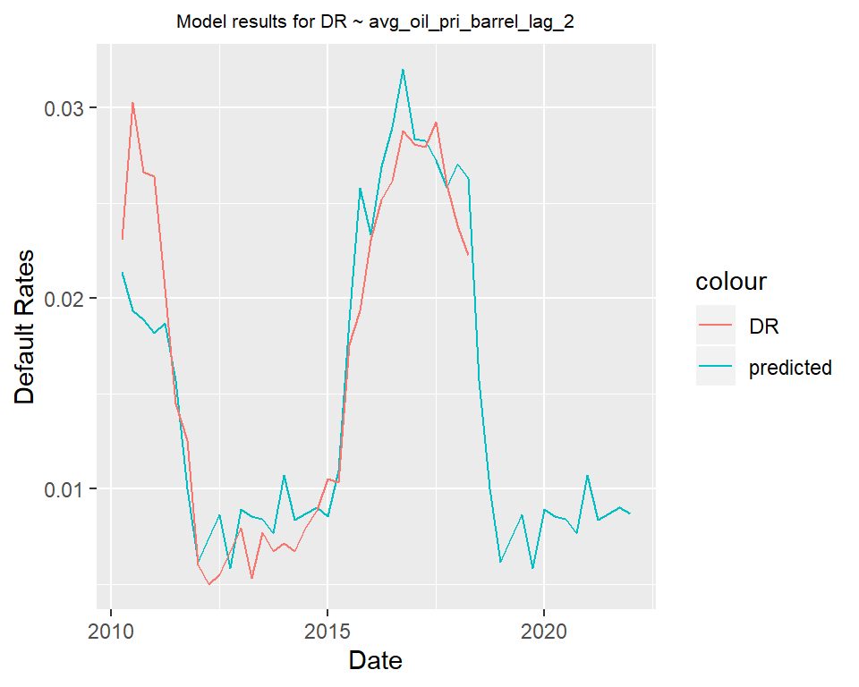

| Date | 31/03/2010 | 30/06/2010 | 30/09/2010 | 31/12/2010 | 31/03/2011 | 30/06/2011 | 30/09/2011 | 31/12/2011 | 31/03/2012 | 30/06/2012 | 30/09/2012 | 31/12/2012 | 31/03/2013 | 30/06/2013 | 30/09/2013 | 31/12/2013 | 31/03/2014 | 30/06/2014 | 30/09/2014 | 31/12/2014 | 31/03/2015 | 30/06/2015 | 30/09/2015 | 31/12/2015 | 31/03/2016 | 30/06/2016 | 30/09/2016 | 31/12/2016 | 31/03/2017 | … |
| --- | --- | --- | --- | --- | --- | --- | --- | --- | --- | --- | --- | --- | --- | --- | --- | --- | --- | --- | --- | --- | --- | --- | --- | --- | --- | --- | --- | --- | --- | --- |
| DR | 0.023055038 | 0.030261483 | 0.026615217 | 0.026397079 | 0.020515981 | 0.014480897 | 0.012552622 | 0.006055856 | 0.005017045 | 0.005498684 | 0.006715283 | 0.007955372 | 0.005346199 | 0.007736280 | 0.006724008 | 0.007176209 | 0.006743516 | 0.007946356 | 0.008899047 | 0.010515682 | 0.010357205 | 0.017554729 | 0.019339632 | 0.023058350 | 0.025162470 | 0.026158368 | 0.028763978 | 0.028075560 | 0.027932088 | … |
| avg_oil_pri_barrel_lag_2 | 68.20000 | 74.63000 | 76.25000 | 78.51000 | 76.82000 | 86.46667 | 104.96000 | 117.36000 | 113.34000 | 109.39667 | 118.49000 | 108.41667 | 109.61333 | 110.08667 | 112.49333 | 102.57667 | 110.27000 | 109.21000 | 108.16667 | 109.70000 | 101.82333 | 76.40333 | 53.91667 | 61.69333 | 50.23333 | 43.57000 | 33.69667 | 45.52333 | 45.78667 | … |
| predicted_values | 0.021348664 | 0.019365346 | 0.018865661 | 0.018168570 | 0.018689846 | 0.015714355 | 0.010010131 | 0.006185381 | 0.007425340 | 0.008641652 | 0.005836835 | 0.008943931 | 0.008574822 | 0.008428823 | 0.007686493 | 0.010745265 | 0.008372275 | 0.008699229 | 0.009021043 | 0.008548090 | 0.010977628 | 0.018818366 | 0.025754324 | 0.023355630 | 0.026890439 | 0.028945728 | 0.031991134 | 0.028343227 | 0.028262003 | … |

## Challenger Model 2

### Summary Regression Results

Summary Results for `DR~Non_oil_ECI_yoy_ch_6QMA+avg_oil_pri_barrel_6QMA_lag_1`

| var | Estimates | VIF | p | se | t | DirectionCheck | Significance | Multicollinearity |
| --- | --- | --- | --- | --- | --- | --- | --- | --- |
| (Intercept) | 0.0470 | NA | 0 | 0.0022 | 21.2519 | NA | PASS | NA |
| Non_oil_ECI_yoy_ch_6QMA | -0.0623 | 1.9272 | 0.0712 | 0.0331 | -1.8815 | PASS | FAIL | PASS |
| avg_oil_pri_barrel_6QMA_lag_1 | -0.0003 | 1.9272 | 0 | 0.0000 | -10.4054 | PASS | PASS | PASS |

| R2 | 0.9115 |
| --- | --- |
| adjR2 | 0.9047 |
| MAPE_test | 0.1608 |

### Diagnostic Tests

Tests for stationarity for `DR~Non_oil_ECI_yoy_ch_6QMA+avg_oil_pri_barrel_6QMA_lag_1`

| Check | Test | statistic | pvalue | Criteria | results | FINAL |
| --- | --- | --- | --- | --- | --- | --- |
| Heteroskedasticity | Breusch-Pagan Test | 1.0048 | 0.6051 | p > 0.1 | Homoskedasticity | PASS |
| Unit Root | ADF Test | -3.7846 | 0.0357 | p < 0.1 | Stationary | PASS |
| Auto-Correlation | Durbin Watson Test | 0.7359 | 0 | p > 0.1 | Auto-Correlation | FAIL |
| Normality | Shapiro-Wilk Test | 0.9636 | 0.4007 | p > 0.1 | Residuals Normally distributed | PASS |

### Forecast

Observed versus Predicted Values for `DR~Non_oil_ECI_yoy_ch_6QMA+avg_oil_pri_barrel_6QMA_lag_1`

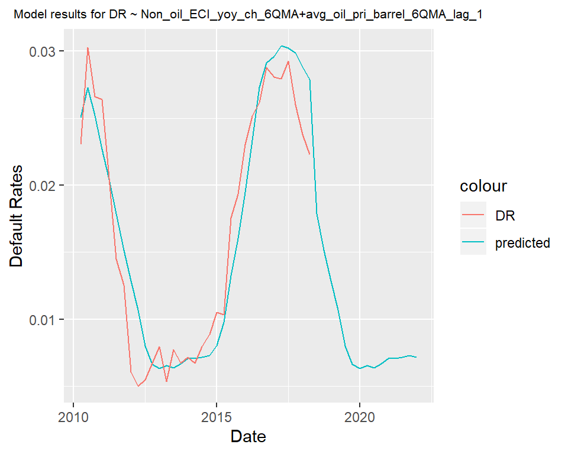

| Date | 31/03/2010 | 30/06/2010 | 30/09/2010 | 31/12/2010 | 31/03/2011 | 30/06/2011 | 30/09/2011 | 31/12/2011 | 31/03/2012 | 30/06/2012 | 30/09/2012 | 31/12/2012 | 31/03/2013 | 30/06/2013 | 30/09/2013 | 31/12/2013 | 31/03/2014 | 30/06/2014 | 30/09/2014 | 31/12/2014 | 31/03/2015 | 30/06/2015 | 30/09/2015 | 31/12/2015 | 31/03/2016 | 30/06/2016 | 30/09/2016 | 31/12/2016 | 31/03/2017 | … |
| --- | --- | --- | --- | --- | --- | --- | --- | --- | --- | --- | --- | --- | --- | --- | --- | --- | --- | --- | --- | --- | --- | --- | --- | --- | --- | --- | --- | --- | --- | --- |
| DR | 0.023055038 | 0.030261483 | 0.026615217 | 0.026397079 | 0.020515981 | 0.014480897 | 0.012552622 | 0.006055856 | 0.005017045 | 0.005498684 | 0.006715283 | 0.007955372 | 0.005346199 | 0.007736280 | 0.006724008 | 0.007176209 | 0.006743516 | 0.007946356 | 0.008899047 | 0.010515682 | 0.010357205 | 0.017554729 | 0.019339632 | 0.023058350 | 0.025162470 | 0.026158368 | 0.028763978 | 0.028075560 | 0.027932088 | … |
| Non_oil_ECI_yoy_ch_6QMA | -0.016736254 | -0.018259206 | -0.006039822 | 0.005074288 | 0.016410291 | 0.025183819 | 0.030637355 | 0.034504767 | 0.041749665 | 0.047995801 | 0.050039886 | 0.051014016 | 0.053620775 | 0.057782351 | 0.058691712 | 0.059757994 | 0.059166445 | 0.058860709 | 0.056823600 | 0.054460995 | 0.049966995 | 0.044616045 | 0.042144870 | 0.038466858 | 0.035184177 | 0.031719635 | 0.030534385 | 0.029758943 | 0.028612615 | … |
| avg_oil_pri_barrel_6QMA_lag_1 | 69.16944 | 62.81167 | 66.78667 | 72.18444 | 76.81278 | 82.93944 | 90.06111 | 96.24278 | 101.39056 | 108.33556 | 111.99389 | 112.76944 | 111.55722 | 111.41611 | 110.27944 | 108.90944 | 109.04167 | 108.80056 | 108.73611 | 106.95778 | 102.59556 | 93.20333 | 85.28389 | 75.62833 | 64.60667 | 53.25222 | 48.10556 | 46.75056 | 44.66611 | … |
| predicted_values | 0.025052349 | 0.027262902 | 0.025178950 | 0.022690392 | 0.020444059 | 0.017858750 | 0.015149148 | 0.012851156 | 0.010686817 | 0.007986630 | 0.006641911 | 0.006323147 | 0.006564155 | 0.006351874 | 0.006673476 | 0.007062950 | 0.007055800 | 0.007155080 | 0.007303423 | 0.008042375 | 0.009773942 | 0.013232728 | 0.016022026 | 0.019464228 | 0.023336406 | 0.027330652 | 0.029117145 | 0.029616355 | 0.030381406 | … |

A work by [Aptivaa](https://www.aptivaa.com)

*info@aptivaa.com*